# Effortless Bayesian Deep Learning through Laplace Redux

JuliaCon 2022

Patrick Altmeyer

Delft University of Technology

Patrick Altmeyer

## Overview

- The Case for Bayesian Deep Learning
- Laplace Redux in Julia 📦
  - From Bayesian Logistic Regression …
  - … to Bayesian Neural Networks.
- Goals and Ambitions 🎯

# The Case for Bayesian Deep Learning

## Bayesian Model Averaging

> Don’t put all your 🥚 in one 🧺.
- In Deep Learning we typically maximise highly non-convex functions full of local optima and saddle points.
- There may be many $\hat\theta_1, ..., \hat\theta_m$ that are slightly different, but yield similar performance.

> […] parameters correspond to a diverse variety of compelling explanations for the data. (Wilson 2020)

$\theta$ is a random variable. Shouldn’t we treat it that way?

$$p(y|x,\mathcal{D}) = \int p(y|x,\theta)p(\theta|\mathcal{D})d\theta
\tag{1}$$

> Intractable!

In practice we typically rely on a **plugin** approximation (Murphy 2022).

$$p(y|x,\mathcal{D}) = \int p(y|x,\theta)p(\theta|\mathcal{D})d\theta \approx p(y|x,\hat\theta)
\tag{2}$$

> Yes, “plugin” is literal … can we do better?

## Enter: Bayesian Deep Learning 🔮

> Yes, we can!

#### Popular approaches include …

MCMC (see [`Turing`](https://turing.ml/dev/tutorials/03-bayesian-neural-network/))

Variational Inference (Blundell et al. 2015)

Monte Carlo Dropout (Gal and Ghahramani 2016)

Deep Ensembles (Lakshminarayanan et al. 2017)

Laplace Redux (Immer et al. (2020),Daxberger et al. (2021))

[figure not shown]

Figure 1: Pierre-Simon Laplace as chancellor of the Senate under the First French Empire. Source: [Wikipedia](https://en.wikipedia.org/wiki/Pierre-Simon_Laplace)

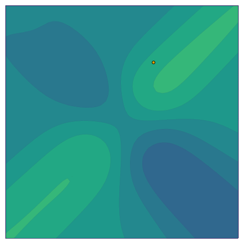

Figure 2: Simulation of changing posteriour predictive distribution. Image by author.

## Laplace Approximation

> We first need to estimate the weight posterior $p(\theta|\mathcal{D})$ …

**Idea** 💡: Taylor approximation at the mode.

- Going through the maths we find that this yields a Gaussian posteriour centered around the MAP estimate $\hat\theta$ (see pp. 148/149 in Murphy (2022)).
- Covariance corresponds to inverse Hessian at the mode (in practice we may have to rely on approximations).

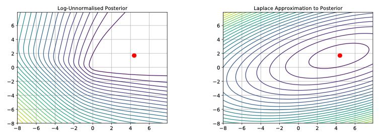

Unnormalized log-posterior and corresponding Laplace Approximation. Source: Murphy (2022).

> Now we can rely on MC or Probit Approximation to compute posterior predictive (classification).

# Laplace Redux in Julia

## [`LaplaceRedux.jl`](https://github.com/juliatrustworthyai/LaplaceRedux.jl) - a small package 📦

[figure not shown]

> What started out as my first coding project Julia …
- Big fan of **learning by coding** so after reading the first chapters of Murphy (2022) I decided to code up Bayesian Logisitic Regression from scratch.
- I also wanted to learn Julia at the time, so tried to hit two birds with one stone.
- **Outcome**: 1. This [blog post](https://towardsdatascience.com/bayesian-logistic-regression-53df017ba90f). 2. I have since been hooked on Julia.

> … has turned into a small package 📦 with great potential.
- When coming across the NeurIPS 2021 paper on Laplace Redux for deep learning (Daxberger et al. 2021), I figured I could step it up a notch.
- **Outcome**: `LaplaceRedux.jl` and another [blog post](https://towardsdatascience.com/go-deep-but-also-go-bayesian-ab25efa6f7b).

So let’s add the package …

```julia
using Pkg
Pkg.add("https://github.com/juliatrustworthyai/LaplaceRedux.jl")
```

… and use it.

```julia
using LaplaceRedux
```

## From Bayesian Logistic Regression …

#### From maths …

We assume a Gaussian prior for our weights …
$$p(\theta) \sim \mathcal{N} \left( \theta | \mathbf{0}, \lambda^{-1} \mathbf{I} \right)=\mathcal{N} \left( \theta | \mathbf{0}, \mathbf{H}_0^{-1} \right)
\tag{3}$$

… which corresponds to logit binary crossentropy loss with weight decay:

$$\ell(\theta)= - \sum_{n}^N [y_n \log \mu_n + (1-y_n)\log (1-\mu_n)] + \\ \frac{1}{2} (\theta-\theta_0)^T\mathbf{H}_0(\theta-\theta_0)
\tag{4}$$

For Logistic Regression we have the Hessian in closed form (p. 338 in Murphy (2022)):

#### … to code

```julia
# Hessian:
function ∇∇𝓁(θ,θ_0,H_0,X,y)
    N = length(y)
    μ = sigmoid(θ,X)
    H = ∑(μ[n] * (1-μ[n]) * X[n,:] * X[n,:]' for n=1:N)
    return H + H_0
end
```

> Gotta love Julia ❤️💜💚

Logistic Regression can be done in `Flux` …

```julia
using Flux
# Initializing weights as zeros only for illustrative purposes:
nn = Chain(Dense(zeros(1,2),zeros(1)))
```

… but now we autograd! Leveraged in `LaplaceRedux`.

```julia
la = Laplace(nn, λ=λ)
fit!(la, data)
```

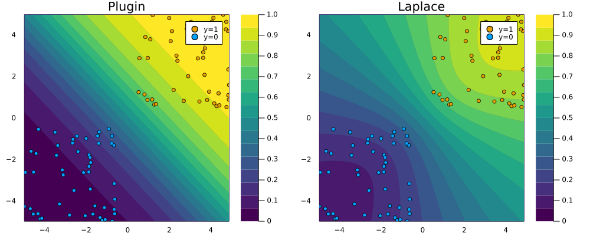

Figure 3: Posterior predictive distribution of Logistic regression in the 2D feature space using plugin estimator (left) and Laplace approximation (right). Image by author.

## … to Bayesian Neural Networks

#### Code

An actual MLP …

```julia
# Build MLP:
n_hidden = 32
D = size(X)[1]
nn = Chain(
    Dense(
      randn(n_hidden,D)./10,
      zeros(n_hidden), σ
    ),
    Dense(
      randn(1,n_hidden)./10,
      zeros(1)
    )
)
```

… same API call:

```julia
la = Laplace(
  nn, λ=λ,
  subset_of_weights=:last_layer
)
fit!(la, data)
```

#### Results

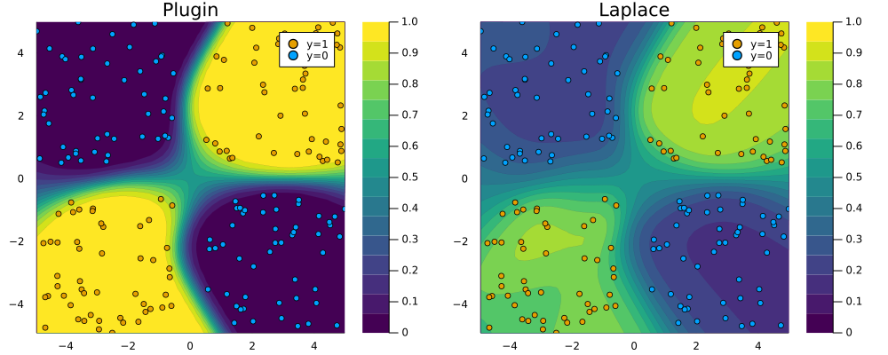

Figure 4: Posterior predictive distribution of MLP in the 2D feature space using plugin estimator (left) and Laplace approximation (right). Image by author.

## A quick note on the prior

Low prior uncertainty $\rightarrow$ posterior dominated by prior. High prior uncertainty $\rightarrow$ posterior approaches MLE.

#### Logistic Regression

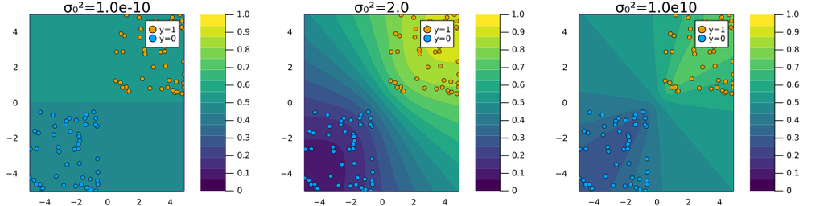

Figure 5: Prior uncertainty increases from left to right (Logsitic Regression). Image by author.

#### MLP

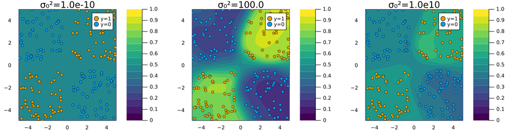

Figure 6: Prior uncertainty increases from left to right (MLP). Image by author.

## A crucial detail I skipped

> We’re really been using linearized neural networks …

#### MC fails

- Could do Monte Carlo for true BNN predictive, but this performs poorly when using approximations for the Hessian.
- Instead we rely on **linear expansion** of predictive around mode (Immer et al. 2020).
- **Intuition**: Hessian approximation involves linearization, then so should the predictive.

> Applying the GNN approximation […] turns the underlying probabilistic model locally from a BNN into a GLM […] Because we have effectively done inference in the GGN-linearized model, we should instead predict using these modified features. — Immer et al. (2020)

[figure not shown]

Figure 7: MC samples from the Laplace posterior (Lawrence 2001).

# Goals and Ambitions 🎯

## JuliaCon 2022 and beyond

#### To JuliaCon …

Learn about Laplace Redux by implementing it in Julia.

Turn code into a small package.

Submit to [JuliaCon 2022](https://juliacon.org/2022/) and share the idea.

#### … and beyond

Package is bare-bones at this point and needs a lot of work.

- **Goal**: reach same level of maturity as Python [counterpart](https://aleximmer.github.io/Laplace/). (Beautiful work btw!)
- **Problem**: limited capacity and fairly new to Julia.
- **Solution**: find contributors 🤗.

[figure not shown]

Photo by [Ivan Diaz](https://unsplash.com/@ivvndiaz?utm_source=unsplash&utm_medium=referral&utm_content=creditCopyText) on [Unsplash](https://unsplash.com/?utm_source=unsplash&utm_medium=referral&utm_content=creditCopyText)

## Specific Goals

#### Easy

- Still missing support for multi-class and regression.
- Due diligence: peer review and unit testing.

#### Harder

- Hessian approximations still quadratically large: use factorizations.
- Hyperparameter tuning: what about that prior?
- Scaling things up: subnetwork inference.
- Early stopping: do we really end up at the mode?
- …

[figure not shown]

Source: [Giphy](https://giphy.com/gifs/theoffice-nbc-the-office-tv-dUHdTk3tvry9NETa67)

## More Resources 📚

> Read on …
- Blog post (1) – Bayesian Logisitic Regression: [[TDS](https://towardsdatascience.com/bayesian-logistic-regression-53df017ba90f), [homepage](https://www.patalt.org/blog/posts/bayesian-logit/)].
- Blog post (2) – Bayesian Deep Learning: [[TDS](https://towardsdatascience.com/go-deep-but-also-go-bayesian-ab25efa6f7b), [homepage](https://www.patalt.org/blog/posts/effortsless-bayesian-dl/)].
- Detailed slide pack generously shared by [Professor José Miguel Hernández-Lobato](https://jmhl.org/): [pdf]
- Package [docs](https://www.patalt.org/CounterfactualExplanations.jl/dev/).

> … or even better: get involved! 🤗

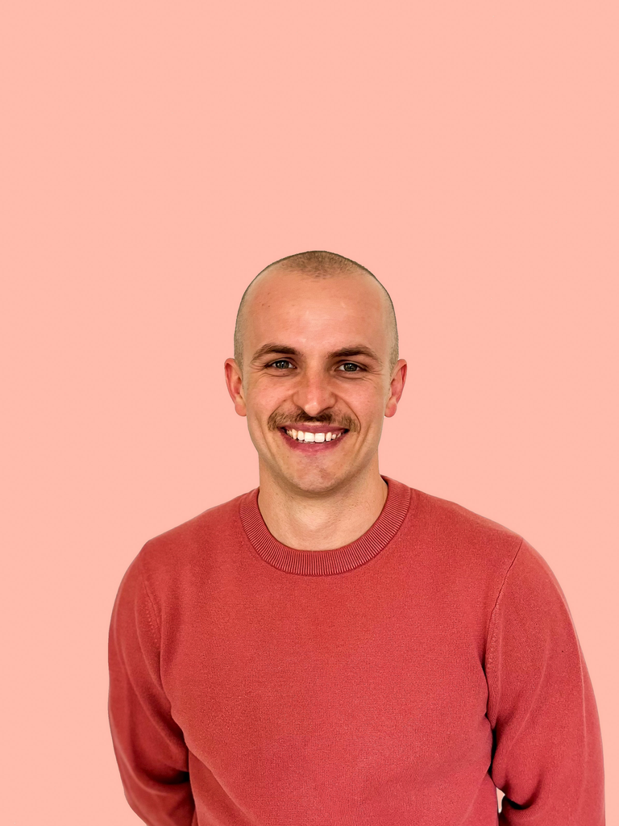

## References

Blundell, Charles, Julien Cornebise, Koray Kavukcuoglu, and Daan Wierstra. 2015. “Weight Uncertainty in Neural Network.” *International Conference on Machine Learning*, 1613–22.

Daxberger, Erik, Agustinus Kristiadi, Alexander Immer, Runa Eschenhagen, Matthias Bauer, and Philipp Hennig. 2021. “Laplace Redux-Effortless Bayesian Deep Learning.” *Advances in Neural Information Processing Systems* 34.

Gal, Yarin, and Zoubin Ghahramani. 2016. “Dropout as a Bayesian Approximation: Representing Model Uncertainty in Deep Learning.” *International Conference on Machine Learning*, 1050–59.

Immer, Alexander, Maciej Korzepa, and Matthias Bauer. 2020. “Improving Predictions of Bayesian Neural Networks via Local Linearization.” https://arxiv.org/abs/2008.08400.

Lakshminarayanan, Balaji, Alexander Pritzel, and Charles Blundell. 2017. “Simple and Scalable Predictive Uncertainty Estimation Using Deep Ensembles.” *Proceedings of the 31st International Conference on Neural Information Processing Systems* (Red Hook, NY, USA), NIPS'17, 6405–16.

Lawrence, Neil David. 2001. “Variational Inference in Probabilistic Models.” PhD thesis, University of Cambridge.

Murphy, Kevin P. 2022. *Probabilistic Machine Learning: An Introduction*. MIT Press.

Wilson, Andrew Gordon. 2020. *The Case for Bayesian Deep Learning*. https://arxiv.org/abs/2001.10995.